# act_report

Who does not love pictures of adorable dogs and puppies? There is a nice humorous account on Twitter [WeRateDogs](https://twitter.com/dog_rates) which publish daily photos and videos of dogs and gives them a rating. Rating system is quite unique on ten points scale the score is mostly greater than 10 i.e. 12/10, 14/10 etc.

Well, I took a bunch of tweets from this account and with help of image recognition algorithm provided by Udacity after a little bit data cleaning and data mining I’ve found the following interesting insights:

The top ten breeds posted on WeRateDogs are (according to image recognition algorithm) **golden retriever, labrador retriever, pembroke, chihuahua, pug, toy poodle, chow, samoyed, pomeranian and malamute**.

On average tweets of the following breeds received higher number of retweets: **bedlington terrier, afghan hound, standard poodle, french bulldog, english springer, saluki, whippet, cocker spaniel, eskimo dog and samoyed**. While average number of retweets is *2668* even last one – Samoyed received on average *4472* retweets per post, other breeds from this list performed even better.

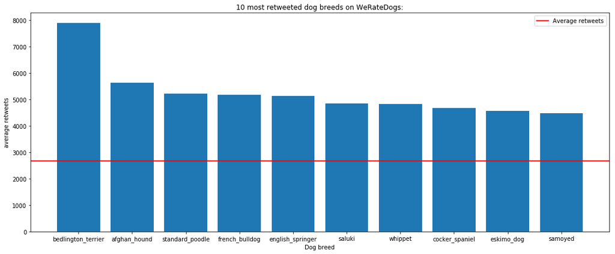

Breeds with highest ratings by WeRateDogs are: **clumber, bouvier des flandres, pomeranian, saluki, briard, tibetan mastiff, border terrier, silky terrier, standard schnauzer, gordon setter**. Average rating numerator is **11.68**, clumber received an astonishing **27.00** average next competitor bouvier des flandres received **13.00** average, the third place with average rating of **12.53** went to pomeranian.

Most common names for dogs are Oliver, Cooper, Charlie and Lucy.

WeRateDogs account is most active during night hours (most of the tweets were published between 24 and 6 hours UTC time).

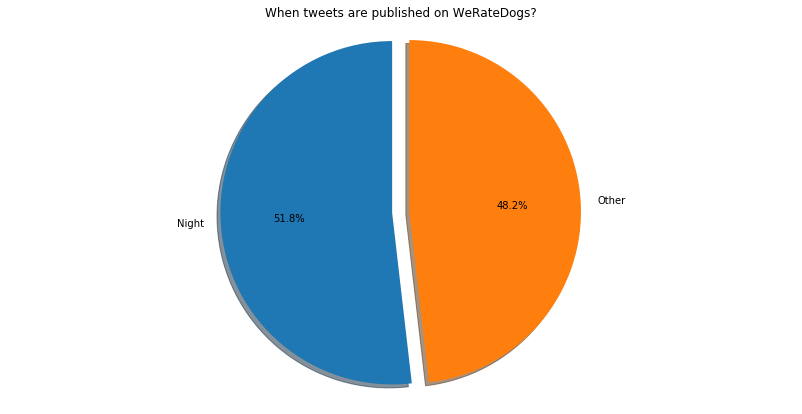